# SOC controls across Washington

Anthony Stewart

2023-11-20

### Introduction

Mapping soil organic carbon (SOC) as a function climatic, topographic, and geologic factors across spatial extents is key for identifying vulnerable SOC stocks. Yet, large, vulnerable SOC stocks are contained in the organic soils of wetlands and can occur in close proximity to non-wetland soils but are controlled and function differently due to saturated soil conditions. Thus, wetland SOC is often omitted or underrepresented in SOC mapping and modeling making it difficult to assess controls compared to non-wetland soil types. Here, we use geospatial data and SOC stocks from 481 soil horizons in 96 pedons in both wetlands and non-wetlands across three ecoregion study areas of the Pacific Northwest to assess climatic, geologic, and topographic controls on SOC.

### Hypotheses

1. WIP is a significant predictor of SOC stock
2. WIP interaction with climate (Precip & Temp) is a significant predictor of SOC stock
3. Geology is a significant predictor of SOC stock

### Data

This dataset has observations of SOC% and SOC stock for 96 locations in Washington state. There are geospatial covariates as well that are used to build models to predict SOC% and/or SOC stock

```
## 'data.frame':    481 obs. of  25 variables:
##  $ X                   : int  1 2 3 4 5 6 7 8 9 10 ...
##  $ sample_ID           : chr  "H-C-01-DNR-WET" "H-C-01-DNR-WET" "H-C-01-DNR-WET" "H-C-01-DNR-WET" ...
##  $ site                : chr  "HOH" "HOH" "HOH" "HOH" ...
##  $ depth_cm            : int  13 40 76 104 11 30 45 75 9 27 ...
##  $ helper              : chr  "H-C-01-DNR-WET|13" "H-C-01-DNR-WET|40" "H-C-01-DNR-WET|76" "H-C-01-DNR-WET|104" ...
##  $ thickness_cm        : int  13 27 36 28 11 19 15 30 9 18 ...
##  $ rock_perc           : num  0 0 5 40 0 15 40 55 0 0 ...
##  $ BD_g_cm3            : num  0.07 0.16 0.51 0.88 0.38 0.49 0.7 0.57 0.72 0.95 ...
##  $ field_texture       : chr  "P" "MP" "MM" "C" ...
##  $ field_texture_binned: chr  "O" "O" "O" "C" ...
##  $ redox               : chr  NA NA NA NA ...
##  $ carbon_perc         : num  39.56 38.31 12.14 2.37 15.65 ...
##  $ carbon_stock_g_cm2  : num  0.376 1.678 2.105 0.352 0.65 ...
##  $ NDYI                : num  0.543 0.543 0.543 0.543 0.579 ...
##  $ Geomorphon_Class    : int  10 10 10 10 10 10 10 10 10 10 ...
##  $ Temp                : num  10.2 10.2 10.2 10.2 10.2 ...
##  $ Precip              : num  3070 3070 3070 3070 3054 ...
##  $ NDVI                : num  0.84 0.84 0.84 0.84 0.862 ...
##  $ MNDWI               : num  -0.477 -0.477 -0.477 -0.477 -0.446 ...
##  $ EVI                 : num  0.455 0.455 0.455 0.455 0.534 ...
##  $ SCI                 : num  0.649 0.649 0.649 0.649 0.648 ...
##  $ GEOLOGIC_AGE        : chr  "Pleistocene" "Pleistocene" "Pleistocene" "Pleistocene" ...
##  $ WIP                 : num  0.873 0.873 0.873 0.873 0.896 ...
##  $ x                   : num  411350 411350 411350 411350 409931 ...
##  $ y                   : num  5295086 5295086 5295086 5295086 5294415 ...
```

Examining covariate predictors using correlation plots

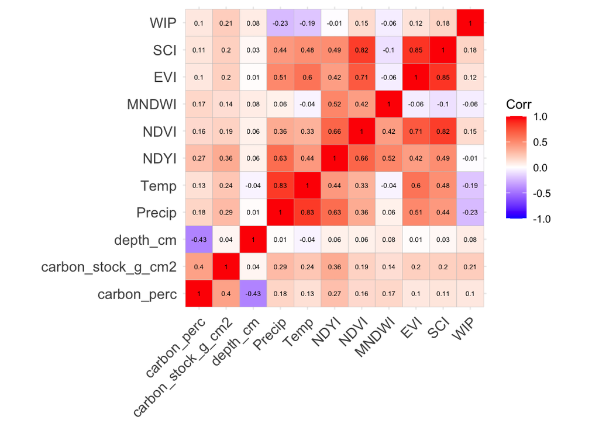

There is weak correlation between `carbon_stock_g_cm2` and the selected covariates. Additionally there is some collinearity between predictors. The spectral predictors such as EVI (Enhanced Vegetation Index) and SCI (Soil Condition Index) are well correlated with each other and also with NDVI (Normalized Difference Vegetation Index). We can remove these based on the correlation coefficient > 0.7.

Now we can begin examining the distribution of carbon stock values in the dataset to choose the appropriate transformation. We also scale and center the numeric predictor variables.

```
## 'data.frame':    481 obs. of  25 variables:
##  $ X                   : num [1:481, 1] -1.73 -1.72 -1.71 -1.71 -1.7 ...
##   ..- attr(*, "scaled:center")= num 241
##   ..- attr(*, "scaled:scale")= num 139
##  $ sample_ID           : chr  "H-C-01-DNR-WET" "H-C-01-DNR-WET" "H-C-01-DNR-WET" "H-C-01-DNR-WET" ...
##  $ site                : chr  "HOH" "HOH" "HOH" "HOH" ...
##  $ depth_cm            : num [1:481, 1] -0.983 -0.306 0.596 1.297 -1.033 ...
##   ..- attr(*, "scaled:center")= num 52.2
##   ..- attr(*, "scaled:scale")= num 39.9
##  $ helper              : chr  "H-C-01-DNR-WET|13" "H-C-01-DNR-WET|40" "H-C-01-DNR-WET|76" "H-C-01-DNR-WET|104" ...
##  $ thickness_cm        : num [1:481, 1] -0.501 0.443 1.05 0.51 -0.636 ...
##   ..- attr(*, "scaled:center")= num 20.4
##   ..- attr(*, "scaled:scale")= num 14.8
##  $ rock_perc           : num [1:481, 1] -0.693 -0.693 -0.477 1.031 -0.693 ...
##   ..- attr(*, "scaled:center")= num 16.1
##   ..- attr(*, "scaled:scale")= num 23.2
##  $ BD_g_cm3            : num [1:481, 1] -1.805 -1.516 -0.391 0.797 -0.809 ...
##   ..- attr(*, "scaled:center")= num 0.632
##   ..- attr(*, "scaled:scale")= num 0.311
##  $ field_texture       : chr  "P" "MP" "MM" "C" ...
##  $ field_texture_binned: chr  "O" "O" "O" "C" ...
##  $ redox               : chr  NA NA NA NA ...
##  $ carbon_perc         : num  39.56 38.31 12.14 2.37 15.65 ...
##  $ carbon_stock_g_cm2  : num  0.376 1.678 2.105 0.352 0.65 ...
##  $ NDYI                : num [1:481, 1] 1.51 1.51 1.51 1.51 1.93 ...
##   ..- attr(*, "scaled:center")= num 0.414
##   ..- attr(*, "scaled:scale")= num 0.0858
##  $ Geomorphon_Class    : num [1:481, 1] 0.777 0.777 0.777 0.777 0.777 ...
##   ..- attr(*, "scaled:center")= num 8.02
##   ..- attr(*, "scaled:scale")= num 2.55
##  $ Temp                : num [1:481, 1] 1.14 1.14 1.14 1.14 1.16 ...
##   ..- attr(*, "scaled:center")= num 8.33
##   ..- attr(*, "scaled:scale")= num 1.61
##  $ Precip              : num [1:481, 1] 1.23 1.23 1.23 1.23 1.21 ...
##   ..- attr(*, "scaled:center")= num 1804
##   ..- attr(*, "scaled:scale")= num 1031
##  $ NDVI                : num [1:481, 1] 0.138 0.138 0.138 0.138 0.407 ...
##   ..- attr(*, "scaled:center")= num 0.829
##   ..- attr(*, "scaled:scale")= num 0.0823
##  $ MNDWI               : num [1:481, 1] 0.475 0.475 0.475 0.475 1.154 ...
##   ..- attr(*, "scaled:center")= num -0.499
##   ..- attr(*, "scaled:scale")= num 0.0467
##  $ EVI                 : num [1:481, 1] -0.171 -0.171 -0.171 -0.171 0.645 ...
##   ..- attr(*, "scaled:center")= num 0.471
##   ..- attr(*, "scaled:scale")= num 0.0965
##  $ SCI                 : num [1:481, 1] -0.0964 -0.0964 -0.0964 -0.0964 -0.1109 ...
##   ..- attr(*, "scaled:center")= num 0.654
##   ..- attr(*, "scaled:scale")= num 0.0511
##  $ GEOLOGIC_AGE        : chr  "Pleistocene" "Pleistocene" "Pleistocene" "Pleistocene" ...
##  $ WIP                 : num [1:481, 1] 1.52 1.52 1.52 1.52 1.61 ...
##   ..- attr(*, "scaled:center")= num 0.436
##   ..- attr(*, "scaled:scale")= num 0.286
##  $ x                   : num [1:481, 1] -1.07 -1.07 -1.07 -1.07 -1.08 ...
##   ..- attr(*, "scaled:center")= num 610372
##   ..- attr(*, "scaled:scale")= num 185155
##  $ y                   : num [1:481, 1] -0.0158 -0.0158 -0.0158 -0.0158 -0.0238 ...
##   ..- attr(*, "scaled:center")= num 5296406
##   ..- attr(*, "scaled:scale")= num 83700
```

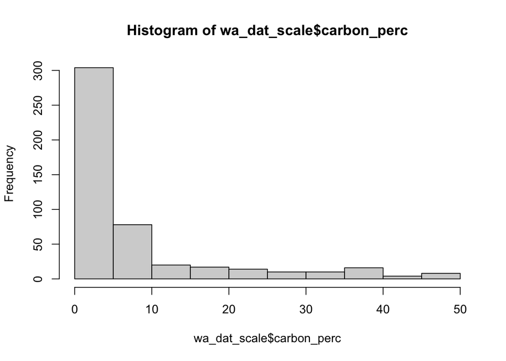

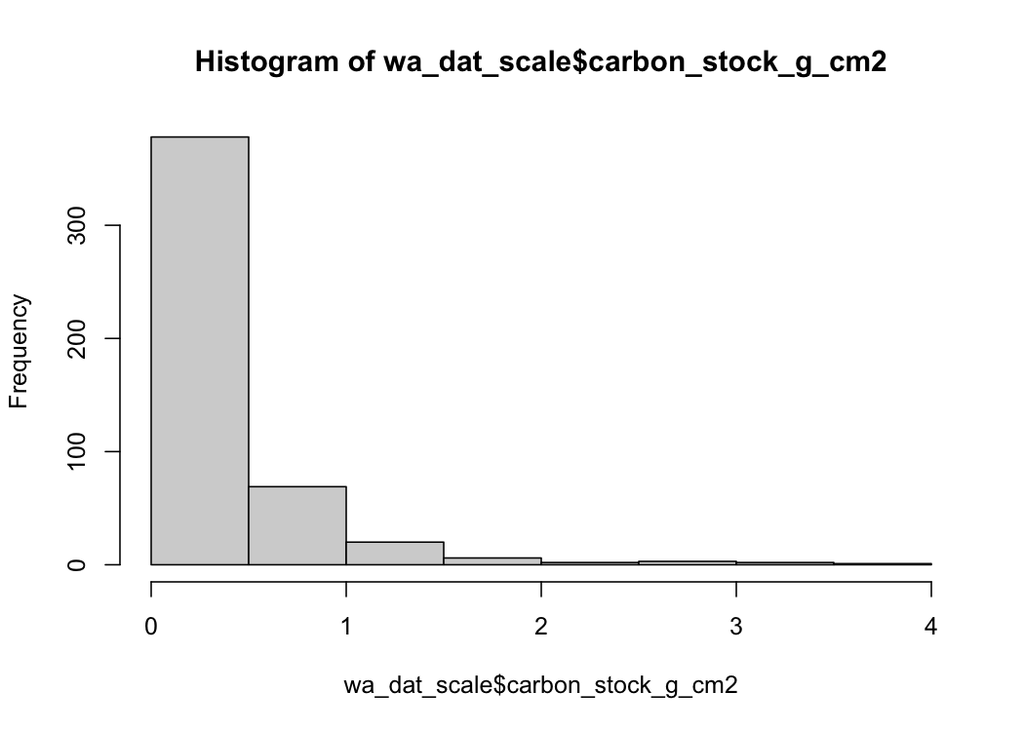

### Explicit parameter model building

Now build models using log transformed carbon stock data. We need to specify that `sample_ID` is a random effect because of the multiple samples at one location. `depth` can be a random slope to adjust model based on how it is affected by depth. We could use a Generalized Linear Model or a Generalized Linear Mixed Model here too but they often fail to converge. I am starting with the log-transformed linear mixed model first to test the hypotheses

```r
# Full model with hypothesized parameters
mod1 <- lmer(log(carbon_stock_g_cm2) ~ WIP * Precip * Temp +
    MNDWI + NDVI + NDYI + (GEOLOGIC_AGE) + (1 + (depth_cm) |
    sample_ID), data = wa_dat_scale, REML = F)
# No interactions
mod2 <- lmer(log(carbon_stock_g_cm2) ~ WIP + Precip + Temp +
    MNDWI + NDVI + NDYI + (GEOLOGIC_AGE) + (1 + (depth_cm) |
    sample_ID), data = wa_dat_scale, REML = F)
# No spectral
mod3 <- lmer(log(carbon_stock_g_cm2) ~ WIP * Precip * Temp +
    (GEOLOGIC_AGE) + (1 + (depth_cm) | sample_ID), data = wa_dat_scale,
    REML = F)
# No geology
mod4 <- lmer(log(carbon_stock_g_cm2) ~ WIP * Precip * Temp +
    MNDWI + NDVI + NDYI + (1 + (depth_cm) | sample_ID), data = wa_dat_scale,
    REML = F)
# No WIP w/ interaction
mod5 <- lmer(log(carbon_stock_g_cm2) ~ Precip * Temp + MNDWI +
    NDVI + NDYI + (GEOLOGIC_AGE) + (1 + (depth_cm) | sample_ID),
    data = wa_dat_scale, REML = F)
# No WIP w/o interaction
mod6 <- lmer(log(carbon_stock_g_cm2) ~ Precip + Temp + MNDWI +
    NDVI + NDYI + (GEOLOGIC_AGE) + (1 + (depth_cm) | sample_ID),
    data = wa_dat_scale, REML = F)
# No climate
mod7 <- lmer(log(carbon_stock_g_cm2) ~ WIP + MNDWI + NDVI + NDYI +
    (GEOLOGIC_AGE) + (1 + (depth_cm) | sample_ID), data = wa_dat_scale,
    REML = F)
# No climate No spectral
mod8 <- lmer(log(carbon_stock_g_cm2) ~ WIP + (GEOLOGIC_AGE) +
    (1 + (depth_cm) | sample_ID), data = wa_dat_scale, REML = F)
# Just WIP
mod9 <- lmer(log(carbon_stock_g_cm2) ~ WIP + (1 + (depth_cm) |
    sample_ID), data = wa_dat_scale, REML = F)
```

Pairwise comparisons between the top, global model and the rest. Note the table contains mod1 multiple times and has been encoded with an additional number

Models

npar

AIC

BIC

logLik

deviance

Chisq

Df

Pr(>Chisq)

Significant

mod2

16

1394.726

1461.540

-681.3628

1362.726

NA

NA

NA

mod1

20

1398.184

1481.701

-679.0918

1358.184

4.541993

4

0.3375972

mod3

17

1397.114

1468.104

-681.5572

1363.114

NA

NA

NA

mod1

20

1398.184

1481.701

-679.0918

1358.184

4.930755

3

0.1769384

mod4

15

1402.769

1465.407

-686.3847

1372.769

NA

NA

NA

mod1

20

1398.184

1481.701

-679.0918

1358.184

14.585647

5

0.0122876

mod5

16

1406.090

1472.904

-687.0450

1374.090

NA

NA

NA

mod1

20

1398.184

1481.701

-679.0918

1358.184

15.906251

4

0.0031476

mod6

15

1405.705

1468.343

-687.8523

1375.705

NA

NA

NA

mod1

20

1398.184

1481.701

-679.0918

1358.184

17.521028

5

0.0036107

mod7

14

1402.863

1461.325

-687.4314

1374.863

NA

NA

NA

mod1

20

1398.184

1481.701

-679.0918

1358.184

16.679065

6

0.0105380

mod8

11

1424.304

1470.238

-701.1519

1402.304

NA

NA

NA

mod1

20

1398.184

1481.701

-679.0918

1358.184

44.120165

9

0.0000013

***

mod9

6

1422.216

1447.271

-705.1081

1410.216

NA

NA

NA

mod1

20

1398.184

1481.701

-679.0918

1358.184

52.032483

14

0.0000028

***

From the ANOVAs it looks like `model 2` & `model 3` performed just as well as `model 1`meaning we should proceed with these. `model 2` removed interactions and `model 3` removed all the spectral metrics but kept interaction. However, `model 2` has 1 less parameter than `model 3` which gives it a lower AIC when compared together.

|  | npar | AIC | BIC | logLik | deviance | Chisq | Df | Pr(>Chisq) |
| --- | --- | --- | --- | --- | --- | --- | --- | --- |
| mod2 | 16 | 1394.726 | 1461.540 | -681.3628 | 1362.726 | NA | NA | NA |
| mod3 | 17 | 1397.114 | 1468.104 | -681.5572 | 1363.114 | 0 | 1 | 1 |

```r
# No MNDWI
mod2.1 <- lmer(log(carbon_stock_g_cm2) ~ WIP + Precip + Temp +
    NDVI + NDYI + (GEOLOGIC_AGE) + (1 + (depth_cm) | sample_ID),
    data = wa_dat_scale, REML = F)
# No MNDWI, No NDVI
mod2.2 <- lmer(log(carbon_stock_g_cm2) ~ WIP + Precip + Temp +
    NDYI + (GEOLOGIC_AGE) + (1 + (depth_cm) | sample_ID), data = wa_dat_scale,
    REML = F)
# No NDYI, No NDVI
mod2.3 <- lmer(log(carbon_stock_g_cm2) ~ WIP + Precip + Temp +
    MNDWI + (GEOLOGIC_AGE) + (1 + (depth_cm) | sample_ID), data = wa_dat_scale,
    REML = F)
# No NDYI, No MNDWI
mod2.4 <- lmer(log(carbon_stock_g_cm2) ~ WIP + Precip + Temp +
    NDVI + (GEOLOGIC_AGE) + (1 + (depth_cm) | sample_ID), data = wa_dat_scale,
    REML = F)
# No NDVI
mod2.5 <- lmer(log(carbon_stock_g_cm2) ~ WIP + Precip + Temp +
    NDYI + MNDWI + (GEOLOGIC_AGE) + (1 + (depth_cm) | sample_ID),
    data = wa_dat_scale, REML = F)
# No NDYI
mod2.6 <- lmer(log(carbon_stock_g_cm2) ~ WIP + Precip + Temp +
    NDVI + MNDWI + (GEOLOGIC_AGE) + (1 + (depth_cm) | sample_ID),
    data = wa_dat_scale, REML = F)
# No spectral
mod2.7 <- lmer(log(carbon_stock_g_cm2) ~ WIP + Precip + Temp +
    (GEOLOGIC_AGE) + (1 + (depth_cm) | sample_ID), data = wa_dat_scale,
    REML = F)
```

| Models | npar | AIC | BIC | logLik | deviance | Chisq | Df | Pr(>Chisq) | Significant |
| --- | --- | --- | --- | --- | --- | --- | --- | --- | --- |
| mod2.1 | 15 | 1393.356 | 1455.994 | -681.6780 | 1363.356 | NA | NA | NA |  |
| mod2 | 16 | 1394.726 | 1461.540 | -681.3628 | 1362.726 | 0.6303396 | 1 | 0.4272308 |  |
| mod2.2 | 14 | 1391.475 | 1449.937 | -681.7375 | 1363.475 | NA | NA | NA |  |
| mod2 | 16 | 1394.726 | 1461.540 | -681.3628 | 1362.726 | 0.7492708 | 2 | 0.6875399 |  |
| mod2.3 | 14 | 1391.954 | 1450.417 | -681.9772 | 1363.954 | NA | NA | NA |  |
| mod2 | 16 | 1394.726 | 1461.540 | -681.3628 | 1362.726 | 1.2287240 | 2 | 0.5409859 |  |
| mod2.4 | 14 | 1394.233 | 1452.695 | -683.1163 | 1366.233 | NA | NA | NA |  |
| mod2 | 16 | 1394.726 | 1461.540 | -681.3628 | 1362.726 | 3.5070131 | 2 | 0.1731657 |  |
| mod2.5 | 15 | 1392.893 | 1455.531 | -681.4467 | 1362.893 | NA | NA | NA |  |
| mod2 | 16 | 1394.726 | 1461.540 | -681.3628 | 1362.726 | 0.1677554 | 1 | 0.6821144 |  |
| mod2.6 | 15 | 1393.914 | 1456.552 | -681.9568 | 1363.914 | NA | NA | NA |  |
| mod2 | 16 | 1394.726 | 1461.540 | -681.3628 | 1362.726 | 1.1879664 | 1 | 0.2757401 |  |
| mod2.7 | 13 | 1393.302 | 1447.588 | -683.6508 | 1367.302 | NA | NA | NA |  |
| mod2 | 16 | 1394.726 | 1461.540 | -681.3628 | 1362.726 | 4.5758474 | 3 | 0.2056238 |  |

Model 2.2 and 2.3 are the lowest AIC and not significantly different from the fit in Model 2. The choice is either between `MNDWI` or `NDYI` to be included in the model with `WIP`, `Precip`, `Temp`, and `Geology.` To test , I want to see if `WIP` interacts with these variables.

```r
# No MNDWI, No NDVI
mod2.2.1 <- lmer(log(carbon_stock_g_cm2) ~ Precip + Temp + WIP:NDYI +
    (GEOLOGIC_AGE) + (1 + (depth_cm) | sample_ID), data = wa_dat_scale,
    REML = F)
# No NDYI, No NDVI
mod2.3.1 <- lmer(log(carbon_stock_g_cm2) ~ Precip + Temp + WIP:MNDWI +
    (GEOLOGIC_AGE) + (1 + (depth_cm) | sample_ID), data = wa_dat_scale,
    REML = F)
```

|  | npar | AIC | BIC | logLik | deviance | Chisq | Df | Pr(>Chisq) | Significant |
| --- | --- | --- | --- | --- | --- | --- | --- | --- | --- |
| mod2.2.1 | 13 | 1409.712 | 1463.998 | -691.8560 | 1383.712 | NA | NA | NA |  |
| mod2.2 | 14 | 1391.475 | 1449.937 | -681.7375 | 1363.475 | 20.23698 | 1 | 6.8e-06 | *** |
| mod2.3.1 | 13 | 1409.469 | 1463.755 | -691.7343 | 1383.469 | NA | NA | NA |  |
| mod2.3 | 14 | 1391.954 | 1450.417 | -681.9772 | 1363.954 | 19.51414 | 1 | 1.0e-05 | *** |

Doesn’t look like there are any significant interactions that improve model fit

Now we can look at the table of all models and compare AICs

| AIC | formula | name | delta |
| --- | --- | --- | --- |
| 1398.18 | WIP * Precip * Temp + MNDWI + NDVI + NDYI + (GEOLOGIC_AGE) + (1 + (depth_cm) \| sample_ID) | mod1 | 6.71 |
| 1394.73 | WIP + Precip + Temp + MNDWI + NDVI + NDYI + (GEOLOGIC_AGE) + (1 + (depth_cm) \| sample_ID) | mod2 | 3.26 |
| 1397.11 | WIP * Precip * Temp + (GEOLOGIC_AGE) + (1 + (depth_cm) \| sample_ID) | mod3 | 5.64 |
| 1402.77 | WIP * Precip * Temp + MNDWI + NDVI + NDYI + (1 + (depth_cm) \| sample_ID) | mod4 | 11.30 |
| 1406.09 | Precip * Temp + MNDWI + NDVI + NDYI + (GEOLOGIC_AGE) + (1 + (depth_cm) \| sample_ID) | mod5 | 14.62 |
| 1405.7 | Precip + Temp + MNDWI + NDVI + NDYI + (GEOLOGIC_AGE) + (1 + (depth_cm) \| sample_ID) | mod6 | 14.23 |
| 1402.86 | WIP + MNDWI + NDVI + NDYI + (GEOLOGIC_AGE) + (1 + (depth_cm) \| sample_ID) | mod7 | 11.39 |
| 1424.3 | WIP + (GEOLOGIC_AGE) + (1 + (depth_cm) \| sample_ID) | mod8 | 32.83 |
| 1422.22 | WIP + (1 + (depth_cm) \| sample_ID) | mod9 | 30.75 |
| 1393.36 | WIP + Precip + Temp + NDVI + NDYI + (GEOLOGIC_AGE) + (1 + (depth_cm) \| sample_ID) | mod2.1 | 1.89 |
| 1391.47 | WIP + Precip + Temp + NDYI + (GEOLOGIC_AGE) + (1 + (depth_cm) \| sample_ID) | mod2.2 | 0.00 |
| 1391.95 | WIP + Precip + Temp + MNDWI + (GEOLOGIC_AGE) + (1 + (depth_cm) \| sample_ID) | mod2.3 | 0.48 |
| 1394.23 | WIP + Precip + Temp + NDVI + (GEOLOGIC_AGE) + (1 + (depth_cm) \| sample_ID) | mod2.4 | 2.76 |
| 1392.89 | WIP + Precip + Temp + NDYI + MNDWI + (GEOLOGIC_AGE) + (1 + (depth_cm) \| sample_ID) | mod2.5 | 1.42 |
| 1393.91 | WIP + Precip + Temp + NDVI + MNDWI + (GEOLOGIC_AGE) + (1 + (depth_cm) \| sample_ID) | mod2.6 | 2.44 |
| 1393.3 | WIP + Precip + Temp + (GEOLOGIC_AGE) + (1 + (depth_cm) \| sample_ID) | mod2.7 | 1.83 |
| 1409.71 | Precip + Temp + WIP:NDYI + (GEOLOGIC_AGE) + (1 + (depth_cm) \| sample_ID) | mod2.2.1 | 18.24 |
| 1409.47 | Precip + Temp + WIP:MNDWI + (GEOLOGIC_AGE) + (1 + (depth_cm) \| sample_ID) | mod2.3.1 | 18.00 |

Looks like the best model fit to the data according to AIC is the `mod2.2` or `mod2.3` which do not include any interactions. The model $R^2$ for `mod2.2` is 0.699 compared to the $R^2$ for `mod2.3` is 0.701

Confidence intervals calculated with bootstrapping between these two models show that `NDYI` is a significant predictor compared to `MNDWI`. Therefore, we use `mod2.2` as our candidate model

|  | Model 2.2 |  |  | Model 2.3 |  |  |
| --- | --- | --- | --- | --- | --- | --- |
| Predictors | Estimates | CI | p | Estimates | CI | p |
| (Intercept) | -1.21 | -1.91 – -0.51 | **0.002** | -1.27 | -1.98 – -0.56 | **0.002** |
| WIP | 0.24 | 0.12 – 0.38 | **<0.001** | 0.28 | 0.15 – 0.40 | **<0.001** |
| Precip | 0.35 | 0.10 – 0.59 | **0.006** | 0.48 | 0.28 – 0.69 | **<0.001** |
| Temp | -0.01 | -0.24 – 0.21 | 0.912 | -0.03 | -0.26 – 0.20 | 0.772 |
| NDYI | 0.16 | 0.00 – 0.33 | **0.046** |  |  |  |
| GEOLOGIC AGE [Miocene-Eocene] | -1.08 | -2.09 – -0.12 | **0.038** | -1.14 | -2.13 – -0.17 | **0.028** |
| GEOLOGIC AGE [Oligocene-Eocene] | 0.21 | -0.54 – 0.95 | 0.546 | 0.26 | -0.50 – 1.00 | 0.462 |
| GEOLOGIC AGE [Pleistocene] | -0.04 | -0.79 – 0.66 | 0.908 | 0.00 | -0.73 – 0.70 | 0.994 |
| GEOLOGIC AGE [pre-Tertiary] | 0.02 | -0.97 – 0.92 | 0.974 | 0.03 | -0.96 – 0.96 | 0.942 |
| GEOLOGIC AGE [Quaternary] | -0.59 | -1.45 – 0.26 | 0.168 | -0.67 | -1.49 – 0.18 | 0.122 |
| MNDWI |  |  |  | 0.11 | -0.01 – 0.23 | 0.070 |
| Random Effects |  |  |  |  |  |  |
| σ<sup>2</sup> | 0.64 |  |  | 0.64 |  |  |
| τ<sub>00</sub> | 0.65 <sub>sample_ID</sub> |  |  | 0.61 <sub>sample_ID</sub> |  |  |
| τ<sub>11</sub> | 0.51 <sub>sample_ID.depth_cm</sub> |  |  | 0.50 <sub>sample_ID.depth_cm</sub> |  |  |
| ρ<sub>01</sub> | 0.94 <sub>sample_ID</sub> |  |  | 0.93 <sub>sample_ID</sub> |  |  |
| ICC | 0.51 |  |  | 0.49 |  |  |
| N | 96 <sub>sample_ID</sub> |  |  | 96 <sub>sample_ID</sub> |  |  |
| Observations | 481 |  |  | 481 |  |  |
| Marginal R<sup>2</sup> / Conditional R<sup>2</sup> | 0.174 / 0.591 |  |  | 0.182 / 0.582 |  |  |

We can now visualize our candidate model 2.2.

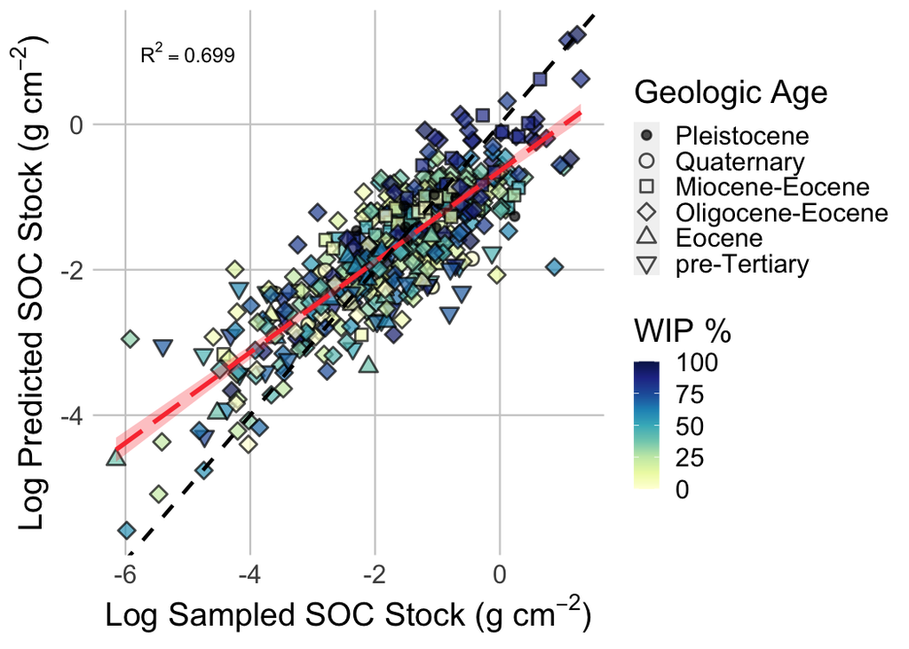

### Dredging for model selection

The `dredge` function can be used to look through multiple combinations of models from a globally defined model. The number of parameters are limited so we run two models: one with the `NDYI` parameter and another with the `MNDWI` parameter included with `Temp`, `Precip`, and `WIP` fully interacting. `GEOLOGIC_AGE` is also included as an additional, non-interaction parameter and random effects are constant.

```r
gmod1 <- lmer(log(carbon_stock_g_cm2) ~ WIP * Temp * Precip *
    NDYI + GEOLOGIC_AGE + (1 + (depth_cm) | sample_ID), data = wa_dat_scale,
    REML = F, na.action = "na.fail")
gmod2 <- lmer(log(carbon_stock_g_cm2) ~ WIP * Temp * Precip *
    MNDWI + GEOLOGIC_AGE + (1 + (depth_cm) | sample_ID), data = wa_dat_scale,
    REML = F, na.action = "na.fail")
dredge1 <- dredge(gmod1, beta = "sd")
dredge2 <- dredge(gmod2, beta = "sd")
```

(Intercept)

GEOLOGIC_AGE

NDYI

Precip

Temp

WIP

NDYI:Precip

NDYI:Temp

NDYI:WIP

Precip:Temp

Precip:WIP

Temp:WIP

NDYI:Precip:Temp

NDYI:Precip:WIP

NDYI:Temp:WIP

Precip:Temp:WIP

NDYI:Precip:Temp:WIP

df

logLik

AICc

delta

weight

24

0

0.1299973

0.2590203

NA

0.1872057

NA

NA

NA

NA

NA

NA

NA

NA

NA

NA

NA

13

-681.7415

1390.262

0.0000000

0.3260432

536

0

0.1361008

0.2516699

NA

0.1831620

NA

NA

NA

NA

-0.0527466

NA

NA

NA

NA

NA

NA

14

-681.1778

1391.257

0.9944499

0.1983047

22

0

NA

0.3486281

NA

0.2158639

NA

NA

NA

NA

NA

NA

NA

NA

NA

NA

NA

12

-683.7578

1392.182

1.9198364

0.1248498

56

0

0.1448841

0.2478062

NA

0.1834030

-0.022364

NA

NA

NA

NA

NA

NA

NA

NA

NA

NA

14

-681.6511

1392.204

1.9410966

0.1235297

152

0

0.1270359

0.2618069

NA

0.1888159

NA

NA

-0.0070658

NA

NA

NA

NA

NA

NA

NA

NA

14

-681.7318

1392.365

2.1023649

0.1139600

32

0

0.1289036

0.2660776

-0.0081215

0.1868638

NA

NA

NA

NA

NA

NA

NA

NA

NA

NA

NA

14

-681.7375

1392.376

2.1137575

0.1133127

(Intercept)

GEOLOGIC_AGE

MNDWI

Precip

Temp

WIP

MNDWI:Precip

MNDWI:Temp

MNDWI:WIP

Precip:Temp

Precip:WIP

Temp:WIP

MNDWI:Precip:Temp

MNDWI:Precip:WIP

MNDWI:Temp:WIP

Precip:Temp:WIP

MNDWI:Precip:Temp:WIP

df

logLik

AICc

delta

weight

56

0

0.0668338

0.3640831

NA

0.2067567

0.0735801

NA

NA

NA

NA

NA

NA

NA

NA

NA

NA

14

-680.9016

1390.704

0.0000000

0.24640525

24

0

0.0907875

0.3500011

NA

0.2136153

NA

NA

NA

NA

NA

NA

NA

NA

NA

NA

NA

13

-682.0105

1390.800

0.0959663

0.23486113

568

0

0.0722226

0.3608701

NA

0.2036170

0.0747569

NA

NA

NA

-0.0550311

NA

NA

NA

NA

NA

NA

15

-680.2725

1391.577

0.8727253

0.15927223

536

0

0.0965784

0.3466353

NA

0.2106885

NA

NA

NA

NA

-0.0544050

NA

NA

NA

NA

NA

NA

14

-681.4154

1391.732

1.0276861

0.14739772

22

0

NA

0.3486281

NA

0.2158639

NA

NA

NA

NA

NA

NA

NA

NA

NA

NA

NA

12

-683.7578

1392.182

1.4778537

0.11768961

64

0

0.0634709

0.3963320

-0.0408569

0.2036933

0.0765553

NA

NA

NA

NA

NA

NA

NA

NA

NA

NA

15

-680.7958

1392.624

1.9194222

0.09437407

By using `dredge` we find that there are a few candidate models that fit the data well.

The difference between the model AICs is negligible. The first includes no interactions between the parameters and removes `Temp` as a predictor. The second includes an interaction between `MNDWI` and `Precip` while also excluding `Temp`.

We can look at the bootstrapped confidence intervals to examine the significance of the predictors between the two models.

|  | Dredge Model 1 |  |  | Dredge Model 2 |  |  |
| --- | --- | --- | --- | --- | --- | --- |
| Predictors | Estimates | CI | p | Estimates | CI | p |
| (Intercept) | -1.21 | -1.86 – -0.52 | **0.002** | -1.25 | -1.89 – -0.56 | **0.002** |
| GEOLOGIC AGE [Miocene-Eocene] | -1.09 | -2.10 – -0.14 | **0.036** | -1.23 | -2.22 – -0.23 | **0.010** |
| GEOLOGIC AGE [Oligocene-Eocene] | 0.21 | -0.53 – 0.92 | 0.554 | 0.25 | -0.48 – 0.97 | 0.472 |
| GEOLOGIC AGE [Pleistocene] | -0.05 | -0.77 – 0.60 | 0.872 | -0.04 | -0.73 – 0.63 | 0.916 |
| GEOLOGIC AGE [pre-Tertiary] | 0.00 | -1.01 – 0.90 | 0.994 | -0.03 | -1.02 – 0.86 | 0.960 |
| GEOLOGIC AGE [Quaternary] | -0.63 | -1.43 – 0.23 | 0.154 | -0.72 | -1.46 – 0.09 | 0.080 |
| NDYI | 0.16 | 0.01 – 0.33 | **0.038** |  |  |  |
| Precip | 0.34 | 0.17 – 0.50 | **<0.001** | 0.47 | 0.35 – 0.59 | **<0.001** |
| WIP | 0.24 | 0.12 – 0.38 | **<0.001** | 0.27 | 0.15 – 0.40 | **<0.001** |
| MNDWI |  |  |  | 0.09 | -0.04 – 0.21 | 0.194 |
| MNDWI × Precip |  |  |  | 0.09 | -0.04 – 0.20 | 0.152 |
| Random Effects |  |  |  |  |  |  |
| σ<sup>2</sup> | 0.64 |  |  | 0.64 |  |  |
| τ<sub>00</sub> | 0.65 <sub>sample_ID</sub> |  |  | 0.58 <sub>sample_ID</sub> |  |  |
| τ<sub>11</sub> | 0.51 <sub>sample_ID.depth_cm</sub> |  |  | 0.50 <sub>sample_ID.depth_cm</sub> |  |  |
| ρ<sub>01</sub> | 0.94 <sub>sample_ID</sub> |  |  | 0.93 <sub>sample_ID</sub> |  |  |
| ICC | 0.50 |  |  | 0.47 |  |  |
| N | 96 <sub>sample_ID</sub> |  |  | 96 <sub>sample_ID</sub> |  |  |
| Observations | 481 |  |  | 481 |  |  |
| Marginal R<sup>2</sup> / Conditional R<sup>2</sup> | 0.175 / 0.591 |  |  | 0.193 / 0.576 |  |  |

Dredge Model 1 includes `NDYI`, `Precip`, `WIP`, and `GEOLOGIC_AGE` as significant predictors. Dredge Model 2 does not have significant confidence intervals for the `MNDWI` and `MNDWIxPrecip` parameters.

There is also minimal differences between the R$^{2}$ between the two models where Dredge Model 1 has R$^{2}$ = 0.699 and Dredge Model 2 has R$^{2}$ = 0.698

We now can examine the plot with the Dredge Model 1

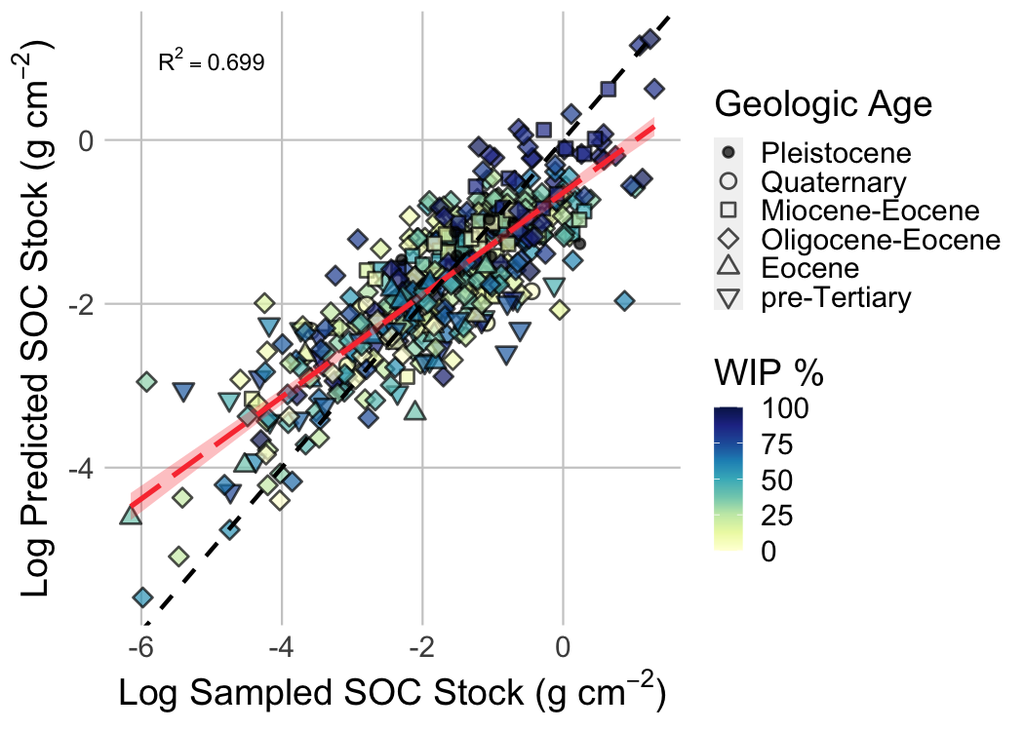

### Random Forest Machine Learning

I also want to try Random Forest in order to see if a more flexible, machine learning model can capture any non-linear relationships with SOC and other variables.

`depth_cm` is included as a predictor here in the data setup

We then use the `tuneRF` to choose the appropriate `mtry` number

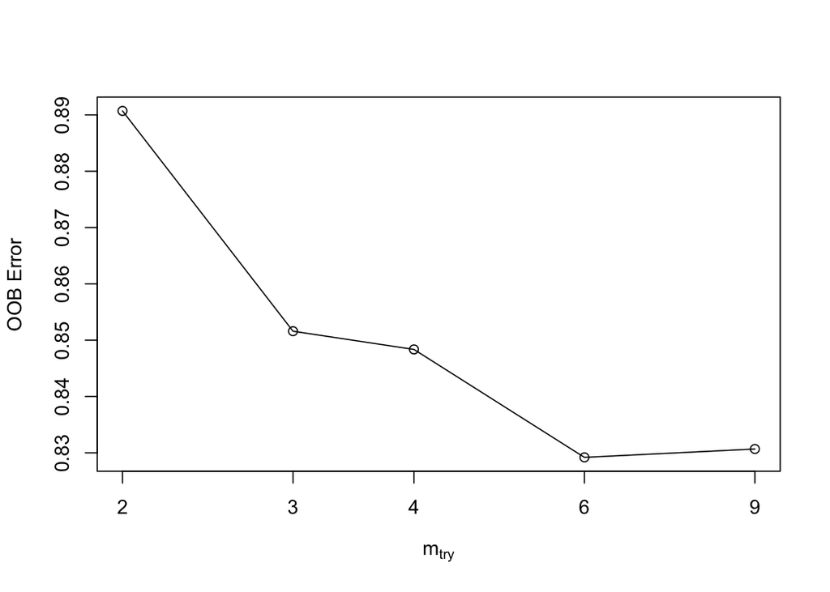

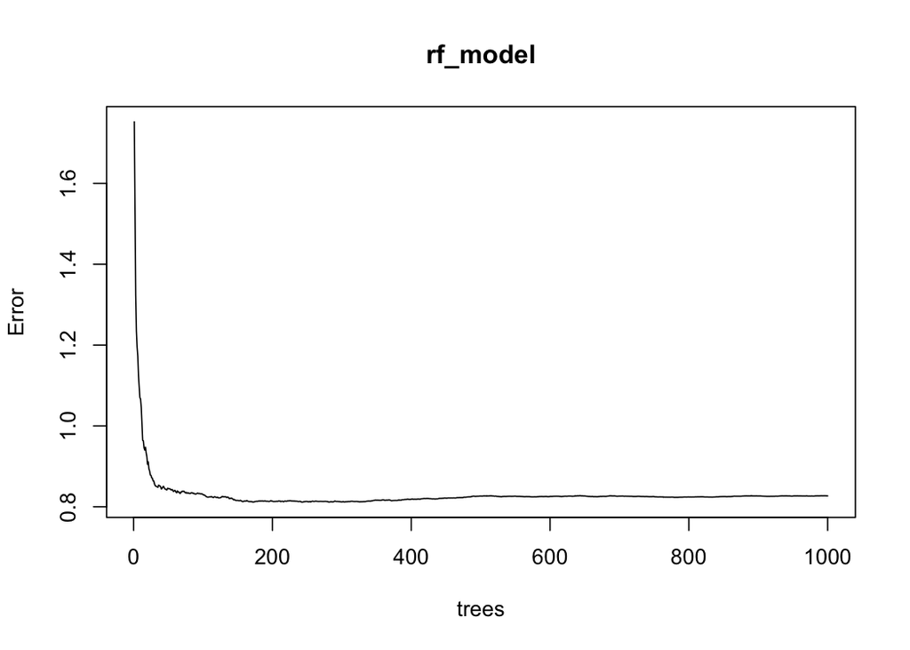

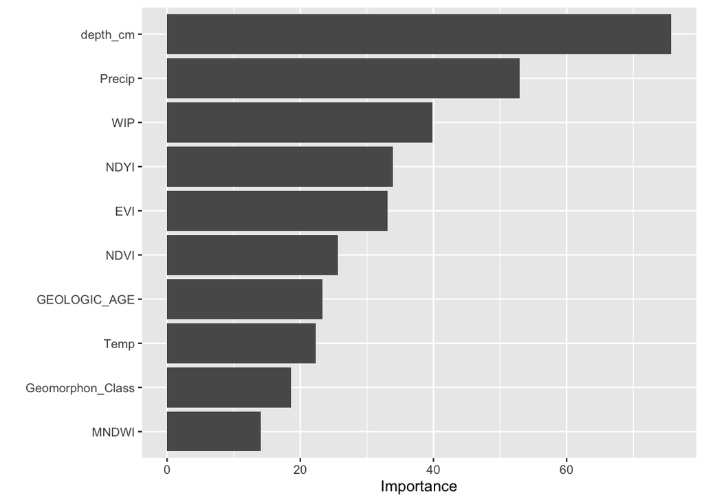

```r
rf_model <- randomForest((carbon_stock_g_cm2) ~ ., ntree = 1000,
    mtry = 6, importance = TRUE, data = full)
plot(rf_model)

rf.full <- predict(rf_model, newdata = full)
vip::vip(rf_model)
```